# Hyper Parameter Tuning -Network Architecture Search

## Modifying Notebook display

```python
from IPython.display import display, HTML

display(HTML(data="""
<style>
    .container#notebook-container    { width: 95%;}
    div#menubar-container     { width: 95%; }
    div#maintoolbar-container { width: 95%; }
</style>
<script>
    document.getElementById("notebook-container").style.margin = "auto";
</script>
"""))
```

## For running the notebook as Google Colab Instance

# mounting the google drive for accessing other necessary files

# Checking the available files in the "Colab Notebooks" folder of the google drive

!ls /content/gdrive/My\ Drive/Colab\ Notebooks/Handwritten\ Digit\ Recognition ``

`import sys`

# changing the current working directory to "Colab Notebooks" folder in the google drive

sys.path.append('/content/gdrive/My Drive/Colab Notebooks/Handwritten Digit Recognition') ``

## For running the notebook as Kaggle Kernel

change directory to the dataset where our custom scripts are uploaded

> `os.chdir("/kaggle/input/handwritten-digit-recognition")`

*handwritten-digit-recognition* is simply a folder name. It can vary based on the dataset you create in kaggle while uploading the python scripts.

load custom module or files or dataset

> `from dataset import load_dataset, train_dev_split, prep_dataset`  
> `from dataset import visualize_data_distribution, visualize_dataset`

reset our working directory

> `os.chdir("/kaggle/working/")`

**NOTE:** The *input directory* is Read-Only. So, we must switch back to the *working directory* for performing any other operation that requires write access. Make sure this note book runs as a part of the dataset you create as said above because all the custom modules are uploaded there.

## Importing Dependencies

```python
# Python Standard Libraries for importing data from binary file
import time    #for calculating time

#core packages
import numpy as np
import matplotlib.pyplot as plt
from matplotlib.patches import Rectangle, Ellipse

# os.chdir("/kaggle/input/handwritten-digit-recognition")

#custom module
from  dataset import load_dataset, train_dev_split, prep_dataset
from dataset import visualize_data_distribution, visualize_dataset

from ffnn import init_layers, init_hyperParams
from ffnn import train, evaluate

from ModelUtils import convert_time
from ModelUtils import save_model, load_model


# # reset our working directory
# os.chdir("/kaggle/working/")


# np.random.seed(1)
%matplotlib inline
```

```python
dataset_size_in_per = 50

train_x_orig, train_y_orig, test_x_orig, test_y_orig = load_dataset(dataset = "mnist", size_in_per = dataset_size_in_per)

print("Sample Size : %d%%\n"%(dataset_size_in_per))
print("Data\t\t\t","Datatype\t\t","Dataset Size")
print("=================================================================")
print("Training Set Images:\t" + str(type(train_x_orig))+"\t",str(train_x_orig.shape))
print("Training Set Labels:\t" + str(type(train_y_orig))+"\t",str(train_y_orig.shape))
print("Test Set Images:\t" + str(type(test_x_orig))+"\t",str(test_x_orig.shape))
print("Test Set Labels:\t" + str(type(test_y_orig))+"\t",str(test_y_orig.shape))
print("=================================================================")
```

```
Sample Size : 50%

Data			 Datatype		 Dataset Size
=================================================================
Training Set Images:	<class 'numpy.ndarray'>	 (30000, 28, 28)
Training Set Labels:	<class 'numpy.ndarray'>	 (30000, 1)
Test Set Images:	<class 'numpy.ndarray'>	 (5000, 28, 28)
Test Set Labels:	<class 'numpy.ndarray'>	 (5000, 1)
=================================================================
```

```python
train_x_split, train_y_split, dev_x_split, dev_y_split = train_dev_split(train_x_orig, train_y_orig)

print("Data\t\t\t\t","Datatype\t\t","Shape")
print("========================================================================")
print("Training Set Images:\t\t" + str(type(train_x_split))+"\t",str(train_x_split.shape))
print("Training Set Labels:\t\t" + str(type(train_y_split))+"\t",str(train_y_split.shape))
print("Development Set Images:\t\t" + str(type(dev_x_split))+"\t",str(dev_x_split.shape))
print("Development Set Labels:\t\t" + str(type(dev_y_split))+"\t",str(dev_y_split.shape))
print("========================================================================")
```

```
Data				 Datatype		 Shape
========================================================================
Training Set Images:		<class 'numpy.ndarray'>	 (25000, 28, 28)
Training Set Labels:		<class 'numpy.ndarray'>	 (25000, 1)
Development Set Images:		<class 'numpy.ndarray'>	 (5000, 28, 28)
Development Set Labels:		<class 'numpy.ndarray'>	 (5000, 1)
========================================================================
```

```python
train_x_norm, train_y_encoded = prep_dataset(train_x_split, train_y_split, num_class = 10)
dev_x_norm, dev_y_encoded= prep_dataset(dev_x_split, dev_y_split, num_class = 10)
test_x_norm, test_y_encoded = prep_dataset(test_x_orig, test_y_orig, num_class = 10)

print("Data\t\t\t","Before Processing\t","After Processing")
print("=================================================================")
print("Training Set Images:\t" + str(train_x_split.shape)+"\t\t"+ str(train_x_norm.shape))
print("Training Set Labels:\t" + str(train_y_split.shape)+"\t\t"+ str(train_y_encoded.shape))
print("Dev Set Images:\t\t" + str(dev_x_split.shape)+"\t\t"+ str(dev_x_norm.shape))
print("Dev Set Labels:\t\t" + str(dev_y_split.shape)+"\t\t"+ str(dev_y_encoded.shape))
print("Test Set Images:\t" + str(test_x_orig.shape)+"\t\t"+ str(test_x_norm.shape))
print("Test Set Labels:\t" + str(test_y_orig.shape)+"\t\t"+ str(test_y_encoded.shape))
print("=================================================================")
```

```
Data			 Before Processing	 After Processing
=================================================================
Training Set Images:	(25000, 28, 28)		(784, 25000)
Training Set Labels:	(25000, 1)		(10, 25000)
Dev Set Images:		(5000, 28, 28)		(784, 5000)
Dev Set Labels:		(5000, 1)		(10, 5000)
Test Set Images:	(5000, 28, 28)		(784, 5000)
Test Set Labels:	(5000, 1)		(10, 5000)
=================================================================
```

## Random Search 2D

### Random Sampling

```python
def sample_network_architecture(search_params,sample_size, num_hidden_units = 'variable', mixed_mode = False):
    hidden_layers_rng = search_params['hidden_layers']
    hidden_units_rng = search_params['hidden_units']

    sample_architectures = []
    while( len(sample_architectures) != sample_size):
        #generating the number of hidden layers
        hidden_layer = np.random.randint(low = hidden_layers_rng[0], high = hidden_layers_rng[1])
        hidden_units = []

        #randomizing the variable and constant hidden units size mode
        if mixed_mode:
            num_hidden_units = np.random.choice(['constant','variable'])

        if num_hidden_units == 'variable':
            #generating variable size hidden units based on number of hidden layers
            for num_layer in range(hidden_layer):
                hidden_unit = np.random.randint(low = hidden_units_rng[0], high = hidden_units_rng[1])
                hidden_unit = (hidden_unit // 100) * 100 #making sure the hidden units are the multiple of 100 for computational ease
                hidden_units.append(hidden_unit)
        elif num_hidden_units == 'constant':
            #generating constant number of hidden units based on the number of hidden layers
            hidden_unit = np.random.randint(low = hidden_units_rng[0], high = hidden_units_rng[1])
            hidden_unit = (hidden_unit // 100) * 100
            hidden_units = [hidden_unit for x in range(1,hidden_layer+1)]

        else:
            raise ValueError("Number of hidden units can be variable or constant only.")

        #making sure no duplicate architecture is present in the sample
        if hidden_units not in sample_architectures:
            sample_architectures.append(hidden_units)

    assert(len(sample_architectures) == sample_size) , 'Samples less than required'

    return sample_architectures
```

```python
#@title Default title text
def search_summary(score, architectures, top_best = 5):
    good_scs = []
    good_archs = []

    #retriving best score and architectures
    sorted_score_index = [b[0] for b in sorted(enumerate(score),key=lambda i:i[1], reverse = True)]
    good_scs = [np.squeeze(score[i]) for i in sorted_score_index[:top_best]]
    good_archs = [architectures[i] for i in sorted_score_index[:top_best]]

    print("Top " + str(top_best) + " Best Architectures\n")
    print("=================+===============+====================================")
    print(" Val Accuracy\t | Hidden Layers | Hidden Units ")
    print("=================+===============+====================================")

    for ind,sc in enumerate(good_scs):
        print(" %.5f\t |  %d\t\t | %s "%( sc, len(good_archs[ind]) , good_archs[ind] ))

    print("=================+===============+====================================")

    print("\nBest Score: %.6f "%(good_scs[0]))
    print("Best Architcture: " + str(good_archs[0]) )

    #best hyper parameter combinations
    best_comb = {"architecture": good_archs[0],
                 "score": good_scs[0]}

    return best_comb
```

```python
def network_architecture_search(search_params, sample_size = 100, with_summary = True):

    #generating Samples for two input parameters
    architectures = sample_network_architecture(search_params,sample_size = sample_size, mixed_mode = True)

    score = []
    best_comb = {}

    #constants
    learning_rate = 0.01
    epoch = 3
    minibatch_size = 128

    toc = time.time()
    for i in range(sample_size):
        print("\nSample: %d | Hidden Layers:%d | Hidden Units: %s "%(i+1, len(architectures[i]), str(architectures[i])))
        print("="*120)

        keep_probs = [0.7 for x in range(len(architectures[i]))]

        layers_dim = init_layers(784, 10, hidden_layers = architectures[i])
        hyperParams = init_hyperParams(alpha = learning_rate, num_epoch = epoch, minibatch_size = minibatch_size, keep_probs = keep_probs)
        history = train(train_x_norm, train_y_encoded, dev_x_norm, dev_y_encoded,layers_dim, hyperParams, initialization = "he", optimizer = 'adam',regularizer = "dropout", verbose = 3)

        val_acc = history["val_accuracy"][-1]
        score.append(val_acc)

        #freeing memory
        layers_dim = hyperParams = history = 0

    tic = time.time() # for calculating entire search time
    hrs, mins, secs , ms = convert_time((tic - toc)*1000)

    print("\n\n %s Total Search Time = %dhr %dmins %dsecs %.2fms %s \n\n"%(('*' * 20),hrs, mins, secs, ms,('*' * 20)))

    if with_summary == True:
        print("Search Summary: \n")
        best_comb = search_summary(score, architectures, top_best = 10)

    return score, architectures, best_comb
```

## Coarse Search

```python
hidden_layers = [1,6]
hidden_units = [300,3000]

search_params = {'hidden_layers':hidden_layers ,
                'hidden_units':hidden_units
}
sample_size = 500

#use sample_size >=200 for better tuning
score, architectures, best_comb = network_architecture_search(search_params , sample_size = sample_size)
```

```
Sample: 1 | Hidden Layers:4 | Hidden Units: [2900, 1200, 2400, 2000]
========================================================================================================================
Training The Model...


Total Training Time = 0hr 4mins 17secs 655.83ms

Sample: 2 | Hidden Layers:1 | Hidden Units: [1500]
========================================================================================================================
Training The Model...


Total Training Time = 0hr 0mins 25secs 907.67ms

Sample: 3 | Hidden Layers:2 | Hidden Units: [700, 900]
========================================================================================================================
Training The Model...


Total Training Time = 0hr 0mins 26secs 348.14ms

Sample: 4 | Hidden Layers:1 | Hidden Units: [2300]
========================================================================================================================
Training The Model...


Total Training Time = 0hr 0mins 35secs 732.86ms

Sample: 5 | Hidden Layers:5 | Hidden Units: [2300, 2200, 1200, 800, 1100]
========================================================================================================================
Training The Model...


Total Training Time = 0hr 3mins 21secs 196.20ms

Sample: 6 | Hidden Layers:4 | Hidden Units: [1200, 1200, 1200, 1200]
========================================================================================================================
Training The Model...


```

[output cut: 3470 more lines]

```
=================+===============+====================================
 0.96260	 |  1		 | [2900]
 0.95840	 |  1		 | [1200]
 0.95720	 |  1		 | [900]
 0.95640	 |  1		 | [600]
 0.95640	 |  1		 | [700]
 0.95620	 |  1		 | [1300]
 0.95600	 |  1		 | [1600]
 0.95580	 |  1		 | [2100]
 0.95540	 |  1		 | [300]
 0.95540	 |  1		 | [2400]
=================+===============+====================================

Best Score: 0.962600
Best Architcture: [2900]
```

## Overall Search Result Sorted

```python
best_sorted_architectures = search_summary(score, architectures, top_best = 500)
```

```
Top 500 Best Architectures

=================+===============+====================================
 Val Accuracy	 | Hidden Layers | Hidden Units
=================+===============+====================================
 0.96260	 |  1		 | [2900]
 0.95840	 |  1		 | [1200]
 0.95720	 |  1		 | [900]
 0.95640	 |  1		 | [600]
 0.95640	 |  1		 | [700]
 0.95620	 |  1		 | [1300]
 0.95600	 |  1		 | [1600]
 0.95580	 |  1		 | [2100]
 0.95540	 |  1		 | [300]
 0.95540	 |  1		 | [2400]
 0.95520	 |  1		 | [500]
 0.95520	 |  1		 | [2800]
 0.95460	 |  1		 | [400]
 0.95440	 |  1		 | [1500]
 0.95440	 |  1		 | [2600]
 0.95440	 |  1		 | [2500]
 0.95380	 |  2		 | [900, 300]
 0.95320	 |  1		 | [2700]
 0.95300	 |  1		 | [2200]
 0.95260	 |  1		 | [1700]
 0.95240	 |  1		 | [2300]
 0.95240	 |  1		 | [1000]
 0.95220	 |  2		 | [2900, 500]
 0.95200	 |  1		 | [2000]
 0.95180	 |  1		 | [1400]
 0.95160	 |  2		 | [2800, 500]
 0.95120	 |  1		 | [1100]
 0.95100	 |  2		 | [1700, 700]
 0.95080	 |  2		 | [1700, 500]
 0.95000	 |  2		 | [1000, 400]
 0.94980	 |  1		 | [1800]
 0.94900	 |  1		 | [1900]
 0.94900	 |  2		 | [900, 500]
 0.94880	 |  2		 | [2100, 400]
 0.94860	 |  2		 | [500, 400]
```

[output cut: 454 more lines]

```
 0.11600	 |  5		 | [2300, 300, 1200, 2500, 800]
 0.11600	 |  5		 | [2700, 300, 1500, 1400, 500]
 0.11600	 |  5		 | [600, 400, 600, 400, 2200]
 0.11600	 |  5		 | [1500, 300, 2200, 600, 2300]
 0.11600	 |  5		 | [2700, 1900, 2600, 400, 2700]
 0.11600	 |  5		 | [600, 2100, 400, 2800, 2300]
 0.11600	 |  5		 | [1300, 1800, 400, 1400, 1900]
 0.11600	 |  5		 | [1200, 1100, 300, 1800, 1200]
 0.11600	 |  5		 | [500, 1500, 500, 2500, 1200]
 0.10680	 |  5		 | [2600, 400, 2600, 1100, 400]
 0.10520	 |  4		 | [1600, 300, 2400, 2000]
=================+===============+====================================

Best Score: 0.962600
Best Architcture: [2900]
```

### Top 10 best Results

```python
best_sorted_architectures = search_summary(score, architectures, top_best = 10)
```

```
Top 10 Best Architectures

=================+===============+====================================
 Val Accuracy	 | Hidden Layers | Hidden Units
=================+===============+====================================
 0.96260	 |  1		 | [2900]
 0.95840	 |  1		 | [1200]
 0.95720	 |  1		 | [900]
 0.95640	 |  1		 | [600]
 0.95640	 |  1		 | [700]
 0.95620	 |  1		 | [1300]
 0.95600	 |  1		 | [1600]
 0.95580	 |  1		 | [2100]
 0.95540	 |  1		 | [300]
 0.95540	 |  1		 | [2400]
=================+===============+====================================

Best Score: 0.962600
Best Architcture: [2900]
```

## Search Analysis

### Sample Distribution based on hidden layers

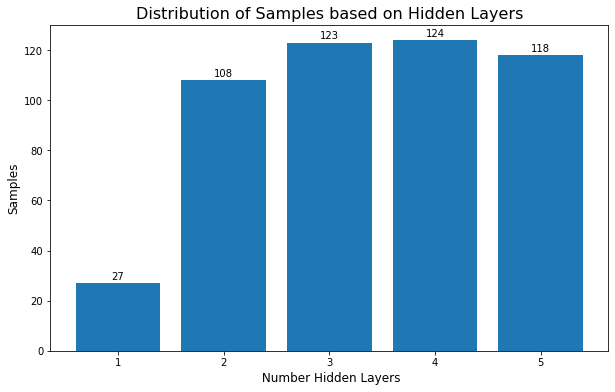

```python
hidden_layers = []

for i in range(len(score)):
    hidden_layers.append(len(architectures[i]))

unique, counts = np.unique(hidden_layers, return_counts=True)

fig, axes = plt.subplots(figsize=(10, 6))
rects = axes.bar(unique, counts)

axes.set_xticks(unique)
axes.set_title("Distribution of Samples based on Hidden Layers", fontsize=16)
axes.set_xlabel(" Number Hidden Layers", fontsize=12)
axes.set_ylabel("Samples", fontsize=12)

for rect in rects:
        height = rect.get_height()
        axes.annotate('{}'.format(height),
                    xy=(rect.get_x() + rect.get_width() / 2, height),
                    xytext=(0, 2),  # 3 points vertical offset
                    textcoords="offset points",
                    ha='center', va='bottom')

plt.show()
```

The distribution seems skewed towards the larger number of hidden networks. It was due to the selection of the hidden units with size multile of 100 during sampling. Doing so, no more than 27 samples of architecture with hidden layer 1 were possible in the range `[300,3000)` without any duplicates.

### Samples with accuracy above 95 %

```python
print("=========+===============+===============+==========================")
print(" Sample\t | Val Accuracy\t | Hidden Layers | Hidden Units")
print("=========+===============+===============+==========================")
for i in range(len(score)):
    if score[i] >= 0.95:
        print(" %d\t | %.5f\t |  %d\t\t | %s "%(i+1, score[i], len(architectures[i]), str(architectures[i])))

print("=========+===============+===============+==========================")
```

```
=========+===============+===============+==========================
 Sample	 | Val Accuracy	 | Hidden Layers | Hidden Units
=========+===============+===============+==========================
 2	 | 0.95440	 |  1		 | [1500]
 4	 | 0.95240	 |  1		 | [2300]
 8	 | 0.95320	 |  1		 | [2700]
 15	 | 0.95240	 |  1		 | [1000]
 18	 | 0.95520	 |  1		 | [500]
 21	 | 0.95200	 |  1		 | [2000]
 32	 | 0.95720	 |  1		 | [900]
 37	 | 0.95640	 |  1		 | [600]
 56	 | 0.95640	 |  1		 | [700]
 57	 | 0.95440	 |  1		 | [2600]
 59	 | 0.95540	 |  1		 | [300]
 60	 | 0.95620	 |  1		 | [1300]
 69	 | 0.95600	 |  1		 | [1600]
 82	 | 0.95300	 |  1		 | [2200]
 83	 | 0.95180	 |  1		 | [1400]
 86	 | 0.95580	 |  1		 | [2100]
 91	 | 0.95840	 |  1		 | [1200]
 95	 | 0.96260	 |  1		 | [2900]
 98	 | 0.95120	 |  1		 | [1100]
 99	 | 0.95460	 |  1		 | [400]
 169	 | 0.95520	 |  1		 | [2800]
 230	 | 0.95260	 |  1		 | [1700]
 234	 | 0.95220	 |  2		 | [2900, 500]
 245	 | 0.95540	 |  1		 | [2400]
 264	 | 0.95440	 |  1		 | [2500]
 371	 | 0.95100	 |  2		 | [1700, 700]
 383	 | 0.95000	 |  2		 | [1000, 400]
 392	 | 0.95380	 |  2		 | [900, 300]
 398	 | 0.95080	 |  2		 | [1700, 500]
 485	 | 0.95160	 |  2		 | [2800, 500]
=========+===============+===============+==========================
```

Best accuracy seems to be for architectures with layer 1 and 2.

The range of hidden unit was `[300,3000)`. The top 10 architeecture included the max range giving the possibility of larger size of hidden units to give better performance so we expand the hidden unit size to 4000

The lower range also gave preety good performance so it is expand it to 100 to check other possibilities

## Fine Search

```python
hidden_layers = [1,3] # 3 is exclusive
hidden_units = [100,4000]

search_params = {'hidden_layers':hidden_layers ,
                'hidden_units':hidden_units
}
sample_size = 500

#use sample_size >=200 for better tuning
score, architectures, best_comb = network_architecture_search(search_params , sample_size = sample_size)
```

```
Sample: 1 | Hidden Layers:2 | Hidden Units: [3500, 400]
========================================================================================================================
Training The Model...


Total Training Time = 0hr 1mins 11secs 861.69ms

Sample: 2 | Hidden Layers:1 | Hidden Units: [200]
========================================================================================================================
Training The Model...


Total Training Time = 0hr 0mins 3secs 727.69ms

Sample: 3 | Hidden Layers:1 | Hidden Units: [2900]
========================================================================================================================
Training The Model...


Total Training Time = 0hr 0mins 43secs 784.02ms

Sample: 4 | Hidden Layers:2 | Hidden Units: [2300, 800]
========================================================================================================================
Training The Model...


Total Training Time = 0hr 1mins 13secs 124.14ms

Sample: 5 | Hidden Layers:2 | Hidden Units: [3600, 3600]
========================================================================================================================
Training The Model...


Total Training Time = 0hr 5mins 36secs 161.16ms

Sample: 6 | Hidden Layers:1 | Hidden Units: [1500]
========================================================================================================================
Training The Model...


```

[output cut: 3470 more lines]

```
=================+===============+====================================
 0.96000	 |  1		 | [3700]
 0.95960	 |  1		 | [800]
 0.95920	 |  1		 | [3100]
 0.95780	 |  1		 | [3800]
 0.95740	 |  1		 | [2100]
 0.95700	 |  1		 | [1100]
 0.95680	 |  1		 | [1300]
 0.95660	 |  1		 | [1200]
 0.95620	 |  2		 | [400, 100]
 0.95600	 |  1		 | [3500]
=================+===============+====================================

Best Score: 0.960000
Best Architcture: [3700]
```

## Overall Search Result Sorted

```python
best_sorted_architectures = search_summary(score, architectures, top_best = 500)
```

```
Top 500 Best Architectures

=================+===============+====================================
 Val Accuracy	 | Hidden Layers | Hidden Units
=================+===============+====================================
 0.96000	 |  1		 | [3700]
 0.95960	 |  1		 | [800]
 0.95920	 |  1		 | [3100]
 0.95780	 |  1		 | [3800]
 0.95740	 |  1		 | [2100]
 0.95700	 |  1		 | [1100]
 0.95680	 |  1		 | [1300]
 0.95660	 |  1		 | [1200]
 0.95620	 |  2		 | [400, 100]
 0.95600	 |  1		 | [3500]
 0.95600	 |  1		 | [900]
 0.95600	 |  1		 | [1000]
 0.95580	 |  1		 | [200]
 0.95580	 |  1		 | [3400]
 0.95520	 |  1		 | [2300]
 0.95520	 |  1		 | [2400]
 0.95520	 |  2		 | [3500, 200]
 0.95500	 |  1		 | [1500]
 0.95500	 |  1		 | [300]
 0.95500	 |  1		 | [500]
 0.95480	 |  2		 | [2100, 100]
 0.95460	 |  1		 | [1400]
 0.95440	 |  1		 | [2800]
 0.95420	 |  1		 | [100]
 0.95420	 |  1		 | [3200]
 0.95420	 |  1		 | [3000]
 0.95420	 |  2		 | [2800, 100]
 0.95400	 |  1		 | [3600]
 0.95400	 |  1		 | [2200]
 0.95380	 |  1		 | [1800]
 0.95380	 |  1		 | [3300]
 0.95360	 |  2		 | [200, 200]
 0.95360	 |  1		 | [1700]
 0.95360	 |  2		 | [1000, 100]
 0.95360	 |  2		 | [3400, 100]
```

[output cut: 454 more lines]

```
 0.91320	 |  2		 | [1100, 3800]
 0.91080	 |  2		 | [200, 2800]
 0.91080	 |  2		 | [300, 2900]
 0.90980	 |  2		 | [400, 3300]
 0.90560	 |  2		 | [200, 3100]
 0.90380	 |  2		 | [100, 1800]
 0.90320	 |  2		 | [300, 3000]
 0.89240	 |  2		 | [100, 2600]
 0.86000	 |  2		 | [100, 2500]
 0.79940	 |  2		 | [100, 3600]
 0.69160	 |  2		 | [100, 3900]
=================+===============+====================================

Best Score: 0.960000
Best Architcture: [3700]
```

### Top 10 best Results

```python
best_sorted_architectures = search_summary(score, architectures, top_best = 10)
```

```
Top 10 Best Architectures

=================+===============+====================================
 Val Accuracy	 | Hidden Layers | Hidden Units
=================+===============+====================================
 0.96000	 |  1		 | [3700]
 0.95960	 |  1		 | [800]
 0.95920	 |  1		 | [3100]
 0.95780	 |  1		 | [3800]
 0.95740	 |  1		 | [2100]
 0.95700	 |  1		 | [1100]
 0.95680	 |  1		 | [1300]
 0.95660	 |  1		 | [1200]
 0.95620	 |  2		 | [400, 100]
 0.95600	 |  1		 | [3500]
=================+===============+====================================

Best Score: 0.960000
Best Architcture: [3700]
```

## Search Analysis

### Sample Distribution based on hidden layers

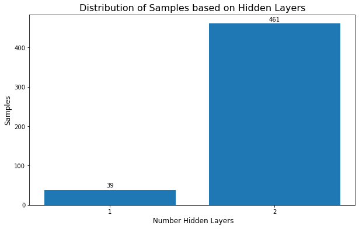

```python
hidden_layers = []

for i in range(len(score)):
    hidden_layers.append(len(architectures[i]))

unique, counts = np.unique(hidden_layers, return_counts=True)

fig, axes = plt.subplots(figsize=(10, 6))
rects = axes.bar(unique, counts)

axes.set_xticks(unique)
axes.set_title("Distribution of Samples based on Hidden Layers", fontsize=16)
axes.set_xlabel(" Number Hidden Layers", fontsize=12)
axes.set_ylabel("Samples", fontsize=12)

for rect in rects:
        height = rect.get_height()
        axes.annotate('{}'.format(height),
                    xy=(rect.get_x() + rect.get_width() / 2, height),
                    xytext=(0, 2),  # 3 points vertical offset
                    textcoords="offset points",
                    ha='center', va='bottom')

plt.show()
```

The skewed distribution is due to the same reason as discussed in Coarse search

### Samples with accuracy above 95 %

```python
print("=========+===============+===============+==========================")
print(" Sample\t | Val Accuracy\t | Hidden Layers | Hidden Units")
print("=========+===============+===============+==========================")
for i in range(len(score)):
    if score[i] >= 0.95:
        print(" %d\t | %.5f\t |  %d\t\t | %s "%(i+1, score[i], len(architectures[i]), str(architectures[i])))

print("=========+===============+===============+==========================")
```

```
=========+===============+===============+==========================
 Sample	 | Val Accuracy	 | Hidden Layers | Hidden Units
=========+===============+===============+==========================
 2	 | 0.95580	 |  1		 | [200]
 3	 | 0.95340	 |  1		 | [2900]
 6	 | 0.95500	 |  1		 | [1500]
 11	 | 0.95920	 |  1		 | [3100]
 22	 | 0.95240	 |  1		 | [2600]
 25	 | 0.95400	 |  1		 | [3600]
 26	 | 0.95500	 |  1		 | [300]
 30	 | 0.95280	 |  1		 | [2000]
 31	 | 0.95960	 |  1		 | [800]
 32	 | 0.95660	 |  1		 | [1200]
 34	 | 0.95500	 |  1		 | [500]
 36	 | 0.95400	 |  1		 | [2200]
 37	 | 0.95320	 |  1		 | [3900]
 38	 | 0.95600	 |  1		 | [3500]
 41	 | 0.95600	 |  1		 | [900]
 42	 | 0.95020	 |  1		 | [400]
 45	 | 0.95420	 |  1		 | [100]
 46	 | 0.95780	 |  1		 | [3800]
 52	 | 0.95740	 |  1		 | [2100]
 64	 | 0.95360	 |  2		 | [200, 200]
 65	 | 0.95520	 |  1		 | [2300]
 68	 | 0.95420	 |  1		 | [3200]
 70	 | 0.95420	 |  1		 | [3000]
 73	 | 0.95380	 |  1		 | [1800]
 75	 | 0.95460	 |  1		 | [1400]
 77	 | 0.95680	 |  1		 | [1300]
 81	 | 0.95060	 |  2		 | [700, 100]
 84	 | 0.95700	 |  1		 | [1100]
 87	 | 0.95480	 |  2		 | [2100, 100]
 89	 | 0.95360	 |  1		 | [1700]
 93	 | 0.95440	 |  1		 | [2800]
 96	 | 0.95100	 |  2		 | [2700, 100]
 97	 | 0.95600	 |  1		 | [1000]
 103	 | 0.95180	 |  1		 | [1600]
 104	 | 0.95220	 |  1		 | [2500]
 107	 | 0.95580	 |  1		 | [3400]
 110	 | 0.95520	 |  1		 | [2400]
```

[output cut: 16 more lines]

```
 295	 | 0.95060	 |  2		 | [3500, 300]
 301	 | 0.95140	 |  2		 | [1100, 600]
 305	 | 0.95120	 |  2		 | [300, 100]
 313	 | 0.95420	 |  2		 | [2800, 100]
 316	 | 0.95620	 |  2		 | [400, 100]
 338	 | 0.95280	 |  2		 | [2100, 200]
 341	 | 0.95220	 |  2		 | [2100, 500]
 375	 | 0.95080	 |  2		 | [2400, 500]
 384	 | 0.95060	 |  2		 | [1300, 200]
 405	 | 0.95220	 |  2		 | [3500, 1000]
 413	 | 0.95360	 |  2		 | [3400, 100]
 457	 | 0.95340	 |  2		 | [2000, 100]
 469	 | 0.95220	 |  2		 | [1600, 100]
 500	 | 0.95000	 |  2		 | [3600, 100]
=========+===============+===============+==========================
```

### Selected Candidates

The candidates are selected from among the top performing candiadtes in both the searches. Some of the candidate with hidden units close to those given below are omitted despite good performance because despite change in some parameters the variation in performance is assumed to be minimum.

```
From my search
========+==============+===============+==============
 Sample | Val Accuracy | Hidden Layers | Hidden Units
========+==============+===============+==============
    1   | 0.96260      |  1            | [2900]
    2   | 0.96000      |  1            | [3700]
    3   | 0.95960      |  1            | [800]
    4   | 0.95920      |  1            | [3100]
    5   | 0.95840      |  1            | [1200]
    6   | 0.95740      |  1            | [2100]
========+==============+===============+==============
```

A number of possible candidates with varied architecture were selected because of their close performance provided that the dropout parameter was constant. Change in this parameter may result in change in the performance of the individual architecture surpassing eachother.

Given the fixed configuration of hyperparameters and data size, the search performed above found architecture with 1 hidden layers to have best performance. Despite that literatures show other architecture with varied number of hidden layers to have better performances as well (which varies a lot based on techniques used in data preprocessing and augmentation, optimization techniques, and other training methodologies like ensamble, committee).

Despite some varition in those techniques the following architectures with varied hidden layer sizes were selected from different literature to test during some of my tuning process.

```
Architecture found best in literatures
=========+===============+============================+===============================================================================
 Sample  |Hidden Layers  | Hidden Units               | Ref
=========+===============+============================+===============================================================================
    9    |  2            | [800,800]                  | Regularization of Neural Networks using DropConnect, lecun's site(simard 0.7)
    8    |  3            | [1500,1000,500]            | Deep Big Simple Neural Nets Excel on Hand- written Digit Recognition
    7    |  4            | [1024,1024,1024,1024]      | Dropout : A Simple Way to Prevent Neural Networks from Overfitting
   10    |  5            | [2500,2000,1500,1000,500]  | Deep Big Simple Neural Nets Excel on Hand- written Digit Recognition
=========+===============+============================+===============================================================================
```

Only the best architecture found during the tuning of the dropout parameter in experiment 6 will be used for further tuning to prepare the final model.

```python
import os
!jupyter-nbconvert --to html 'Hyper Parameter Tuning -Network Architecture Search .ipynb' --output Experiments/experiment-5/architecture_search_500_samples_complete_analysis.html
```

```
[NbConvertApp] Converting notebook Hyper Parameter Tuning -Network Architecture Search .ipynb to html
[NbConvertApp] Writing 1078108 bytes to Experiments/experiment-5/architecture_search_500_samples_complete_analysis.html
```